# **Galactic Dynamo Simulations**

**Abstract:** *In this project, I solved the mean field dynamo equations both neglecting and including the $\alpha-\Omega$ effects in a thin disk approximation. In the thin disk approximation, the radial dependence is completely ignored and consequently the radial derivatives involved in the equations are dropped. In addition to solving the equations, the numerical technique used, Runge-Kutta algorithm in this case, was closely investigated. The suitable choice of order of the algorithm was hinted at.*

### **Introduction**

Galaxies like the Milky way have large magnetic fields with significant energy densities. Dynamo theories try explaining the processes underpinning the amplification and persistence of small seed magnetic fields within a galaxy. Employing galactic dynamo simulations, we can, thus,investigate the intricate processes underlying their generation and sustenance. In order to accurately predict the behaviour of such galactic processes, we need to account for certain factors such as:

- **Characterisitics of the Magnetic Field** which factors in the interactions of the conducting fluids within the galaxy
- **Rotation** of the galactic plane which generates the so called $\alpha-\Omega$ effect
- **Turbulence** within the conducting fluids which happens to be an important mechanism for the amplification of the seed magnetic field

[figure not shown]

PC: @[Amit Seta](https://ras.ac.uk/events-and-meetings/ras-meetings/galactic-magnetic-fields-connecting-theory-simulations-and)  
This project entails the solving of mean field dynamo equations both neglecting and including the $\alpha-\Omega$ effects in a thin disk. In the thin disk approximations, the radial dependence is completely obliterated and consequently the radial derivatives involved in the equations are washed away. In addition to solving the equations, the numeric technique used, Runge-Kutta algorithm in this case, needs to be closely investigated. The right balance of speed and accuracy needs to be determined and the order of the RK algorithm to be used should be hinted at.

### **Mean Field Dynamo Equations**

Assuming the $\alpha$-effect and turbulent diffusivity to be represented by scalar quantities, the mean field dynamo equations reduce to the following simple form: $$ \frac{\partial \overline{\boldsymbol{B}}}{\partial t}=\nabla \times(\overline{\boldsymbol{V}} \times \overline{\boldsymbol{B}})+\nabla \times(\alpha \overline{\boldsymbol{B}})-\nabla \times \beta \nabla \times \overline{\boldsymbol{B}} $$ If $\beta$ is independent of position, $\nabla \times \beta \nabla \times \overline{B} = \beta \nabla^{2}\overline{B}$ since $\nabla \cdot \overline{B}=0.$
We will be working in the cylindrical coordinate system since we are assuming our galaxy to be an axially symmetric thin disk. Thus, $\vec{B} = (B_r,B_\phi,B_z)$. Thus, the mean field dynamo equations for an axially symmetric thin disc are as follows: \begin{align} &\frac{\partial B_{r}}{\partial t} =-\frac{\partial}{\partial z}(\alpha\overline{B}_{\phi})+\beta\frac{\partial^{2}B_{r}}{\partial z^{2}}+\beta\frac{\partial}{\partial r}\left[\frac{1}{r}\frac{\partial}{\partial r}(r\overline{B}_{r})\right], \\ &\frac{\partial\overline{B}_{\phi}}{\partial t} =S\overline{B}_{r}+r\frac{\partial\Omega}{\partial z}\overline{B}_{z}+\frac{\partial}{\partial z}(\alpha\overline{B}_{r})-\frac{\partial}{\partial r}(\alpha\overline{B}_{z})+\beta\frac{\partial^{2}\overline{B}_{\phi}}{\partial z^{2}}+\beta\frac{\partial}{\partial r}\left[\frac{1}{r}\frac{\partial}{\partial r}(r\overline{B}_{\phi})\right] \\ & \\ &\frac{\partial\overline{B}_{z}}{\partial t} =\frac{1}{r}\frac{\partial}{\partial r}(r\alpha\overline{B}_{\phi})+\beta\frac{\partial^{2}\overline{B}_{z}}{\partial z^{2}}+\beta\frac{\partial}{\partial r}\left[\frac{1}{r}\frac{\partial}{\partial r}(r\overline{B}_{z})\right], \end{align} where, S is the shear velocity rate.
Neglecting the radial derivatives and the $B_z$ term completely under the thin disk approximation, we have: \begin{aligned} &\frac{\partial\overline{B}_{r}}{\partial t}=-\frac{\partial}{\partial z}(\alpha\overline{B}_{\phi})+\frac{\partial^{2}\overline{B}_{r}}{\partial z^{2}},\\&\frac{\partial\overline{B}_\phi}{\partial t}=DS\overline{B}_r+\frac{\partial^2\overline{B}_\phi}{\partial z^2}, \end{aligned} where, $\alpha$ and S can in general depend on r.

#### Neglecting the $\alpha-\Omega$ effects: Diffusion Equation

Neglecting the alpha effect and the stretching term $\vec{v} \times \vec{B}$, we have: \begin{equation} \frac{\partial\bar{\mathbf{B}}}{\partial t}=\eta\nabla^{2}\bar{\mathbf{B}} \end{equation} Thus, the $B_r$ and $B_\phi$ components evolves as follows: \begin{equation} \frac{\partial B_r}{\partial\tilde{t}}=\left(\frac{\partial^2B_r}{\partial\tilde{z}^2}\right) \end{equation} \begin{equation} \frac{\partial B_\phi}{\partial\tilde{t}}=\left(\frac{\partial^2B_\phi}{\partial\tilde{z}^2}\right) \end{equation}

### **Runge-Kutta Method**

#### **The Algorithm**

It is by far the most popular algorithm to solve any system of coupled differential equations. Despite being primarily based on Taylor expansion, Runge-Kutta (RK) approaches typically yield better algorithms for solving ODEs with the same step size and stability. Actually, it's a generalisation of the Predictor-Corrector and Euler approaches. Consider the following: \begin{align} \frac{d y}{d x} & =f(y(x), x) \\ \int_{y_n}^{y_n+h} d y & =\int_{x_n}^{x_n+h} f(y(x), x) d x \\ y\left(x_n+h\right) & =y\left(x_n\right)+\int_{x_n}^{x_n+h} f(y(x), x) d x \end{align} Let's use the midpoint method to estimate the above integral. \begin{align} \bar{x}_n & =\frac{\left(x_n+h\right)+x_n}{2}=x_n+\frac{h}{2} \\ y\left(x_n+h\right) & =y\left(x_n\right)+h f\left(y\left(x_n+h / 2\right), x_n+h / 2\right)+\mathcal{O}\left(h^3\right) \end{align} Since $y\left(x_n+h / 2\right)$ is unknown, we use the Forward Euler to approximate it: $$ y\left(x_n+h / 2\right)=y\left(x_n\right)+\frac{h}{2} f\left(y\left(x_n\right), x_n\right) $$ From here, we obtain the second order Runge-Kutta (RK2) as follows: \begin{align} \kappa_1 & =h f\left(y\left(x_n\right), x_n\right) \\ \kappa_2 & =h f\left(y\left(x_n\right)+\kappa_1 / 2, x_n+h / 2\right) \\ y\left(x_n+h\right) & \approx y\left(x_n\right)+\kappa_2+\mathcal{O}\left(h^3\right) \end{align} Using the Simpson rule to estimate the integral, we will get the fourth order Runge-Kutta where we define: \begin{align} & \kappa_1=h f\left(y\left(x_n\right), x_n\right) \\ & \kappa_2=h f\left(y\left(x_n\right)+\kappa_1 / 2, x_n+h / 2\right) \\ & \kappa_3=h f\left(y\left(x_n\right)+\kappa_2 / 2, x_n+h / 2\right) \\ & \kappa_4=h f\left(y\left(x_n\right)+\kappa_3, x_n+h\right) \end{align} which when combined, yield us: \begin{equation} y\left(x_n+h\right)=y\left(x_n\right)+\frac{1}{6}\left(\kappa_1+2 \kappa_2+2 \kappa_3+\kappa_4\right)+\mathcal{O}\left(h^5\right) \end{equation}.

#### **Truncation Error**

The error accummulated at every successive stage of the iterated algorithm if referred to as the **truncation error**. In the case of RK4, it will scale as $h^5$ and the error can thus be written as $Ch^5$, where C is a constant which is independent of dt but is dependent on the starting time $t_0$. Therefore, for the estimation of the truncation error we would assume that C remains constant over the interval $[t_0,t_0 + h]$.
Let u be the approximate solution to x(t) at t0 + h obtained by carrying out a one-step fourth order Runge-Kutta approximation: $$x(t)=u+Ch^5$$ Let v be the approximate solution to x(t) at t0 + h obtained by carrying out a two-step fourth order Runge-Kutta approximation (with step sizes of h/2) $$ x(t)=v +2C\left(\frac{h}{2}\right)^5$$ Substracting these two equations we obtain: $$0=u-v+C\left(1-2^{-4}\right)h^{5}$$ from which we get the local truncation error as: $$Error = Ch^{5}={\frac{u-v}{1-h^{-4}}}\approx u-v$$ There are adaptive algorithms which monitor this error at every computational step and accordingly adjust h to minimise the local truncation error.

## **Task-1: Solving the diffusion equation neglecting the $\alpha-\Omega$ effect**

```python
# Importing the relevant libraries
import numpy as np
import matplotlib.pyplot as plt
from tqdm import tqdm
from celluloid import Camera
plt.rcParams.update({"text.usetex": True, "font.family": "Helvetica"})
```

##### **Defining the mesh and the spatial derivative**

I will be solving the diffusion equation by discretising the spatial and temporal dimensions. Let's look at the simple 1-D diffusion equation to understand the approach: $$ \frac{\partial B}{\partial t} = \eta \frac{\partial^2 B}{\partial t^2}$$ where, $\eta$ is defined as the diffusivity parameter which is a scalar in our case. \ Discretising the spatial dimension using finite differencing, we get: $$\frac{\partial B}{\partial t} = \eta \frac{B_{i+1} - 2B_i + B_{i-1}}{(\delta x)^2}$$ Using the notion of a derivative for the temporal dimension, we have: $$\frac{B_{i}(t+\delta t) - B_{i}(t)}{\delta t} = \eta \frac{B_{i+1} - 2B_i + B_{i-1}}{(\delta x)^2}$$ $$\implies B_{i}(t+\delta t) = B_{i}(t) + \frac{\eta \delta t}{(\delta x)^2} (B_{i+1} - 2B_i + B_{i-1})$$ It is important to remember the Courant-Friedrichs-Lewy (CFL) condition while defining the mesh parameters. The CFL conditions states that: $$\frac{\delta x}{\delta t} < c$$ where, c is the speed of light which can be taken to be equal to 1.

```python
# Defining the mesh parameters
h = 0.1 # step size along z-axis
k = 0.2 # step size along t-axis
eta = 1e-2 # Defining the eta parameter
z = np.arange(0,10+h,h) # Taking z from 0 to 10 a.u.
t = np.arange(0,1000+k,k) # Taking t from 0 to 10 a.u.
M = len(t) # Number of grid points along t-axis
N = len(z) # Number of grid points along z-axis
# Creating the mesh
br = np.zeros((N,M))
bp = np.zeros((N,M))
```

```python
# Defining the spatial derivative using the finite difference method
def x_der(u,dx,t):
    global eta
    k = np.zeros_like(u,dtype=np.float64)
    for i in range(1,len(u)-1):
        k[i] = eta*(u[i - 1] - 2 * u[i] + u[i + 1])/dx**2

    return k
```

##### **Defining the boundary conditions and the initial condition**

```python
# Defining the initial condition for B_r and B_p
def initial_br(z):
    return (z**2/2 - 10*z*np.sin(3*z*np.pi/180))*10

def initial_bp(z):
    return 5*z - z**2/2
```

```python
# Incorporating the Boundary Conditions
br[0,:] = 0
br[-1,:] = 0
bp[0,:] = 0
bp[-1,:] = 0

# Incorporating the Initial Conditions
br[:,0] = initial_br(z)
bp[:,0] = initial_bp(z)
```

##### **Implementing the RK4 Method**

```python
def RK4(u,t,dx,dt,f):
    k1 = dt*f(u,dx,t)
    k2 = dt*f(u+k1*0.5,dx,t+dt/2)
    k3 = dt*f(u+k2*0.5,dx,t+dt/2)
    k4 = dt*f(u+k3,dx,t+dt)

    k = (1/6)*(k1+2*k2+2*k3+k4)
    u_new = u + k
    return u_new
```

```python
# Iteratively Solving the DE
for i in tqdm(range(1,M-1)):
    u = br[:,i-1]
    v = bp[:,i-1]
    next_t = t[i]
    br[:,i] = RK4(u,next_t,h,k,x_der)
    bp[:,i] = RK4(v,next_t,h,k,x_der)
```

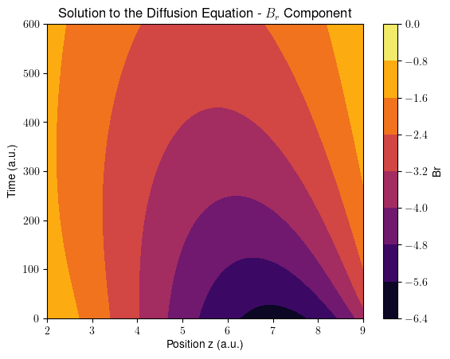

```python
# Plotting the contour plot for B_r component
plt.contourf(z,t,br.transpose(),cmap='inferno')
plt.ylabel('Time (a.u.)')
plt.xlabel('Position z (a.u.)')
plt.xlim(2,9)
plt.ylim(0,600)
plt.colorbar(label='Br')
plt.title('Solution to the Diffusion Equation - $B_r$ Component')
plt.show()
```

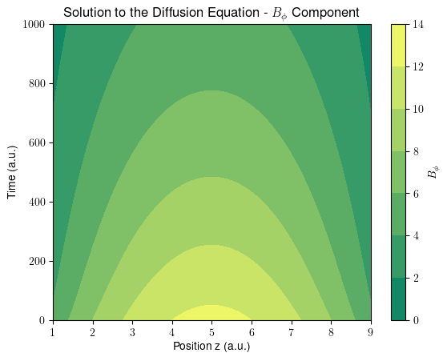

```python
# Contour plot for the B_phi component
plt.contourf(z,t,bp.transpose(),cmap='summer')
plt.ylabel('Time (a.u.)')
plt.xlabel('Position z (a.u.)')
plt.xlim(1,9)
plt.colorbar(label='$B_\phi$')
plt.title('Solution to the Diffusion Equation - $B_\phi$ Component')
plt.show()
```

The following animation shows how $B_r$ evolves spatially with time:

[figure not shown]

Given we started with a sinusoidal seed field, it converges quickly to its eigenmode which is sinusoidal itself. The negative value comes from the structure of the seed field itself. The initial conditions have been chosen carefully to make sure that Dirichlet Boundary Conditions are satisfied at all time instants including the initial time. We can look at the final and the initial state together to have a better understanding of the evolution:

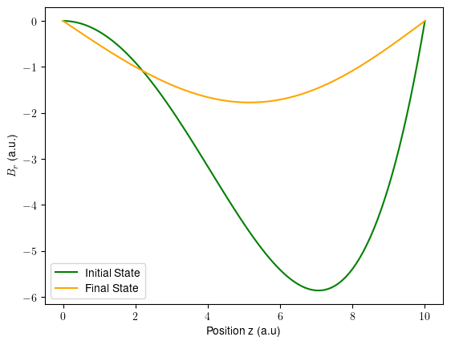

```python
plt.plot(z,br[:,0],color='green',label='Initial State')
plt.plot(z,br[:,len(t)-2],color='orange',label='Final State')
plt.xlabel('Position z (a.u)')
plt.ylabel('$B_r$ (a.u.)')
plt.legend()
plt.show()
```

Given the fact that we started with a quadratic function instead of a sinusoidal one, $B_\phi$ converges slowly to its sinusoidal eigenmode:

[figure not shown]

It is quite clear from these two examples that the initial conditions strongly affect the **convergence** to any of the eigenmodes. The initial and final states of the $B_\phi$ looks something like below:

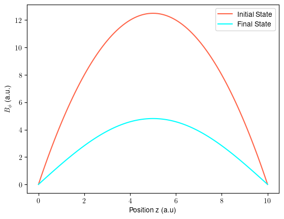

```python
plt.plot(z,bp[:,0],color='tomato',label='Initial State')
plt.plot(z,bp[:,len(t)-2],color='cyan',label='Final State')
plt.xlabel('Position z (a.u)')
plt.ylabel('$B_\phi$ (a.u.)')
plt.legend()
plt.show()
```

The pitch angle ($\theta_p$) is defined as follows: $$\theta_p = \tan^{-1}\left(\frac{Mean Radial Component (\overline{B_r})}{Mean Azimuthal Component (\overline{B_\phi})}\right)$$ We can define a function to calculate and plot the evolution of the pitch angle:

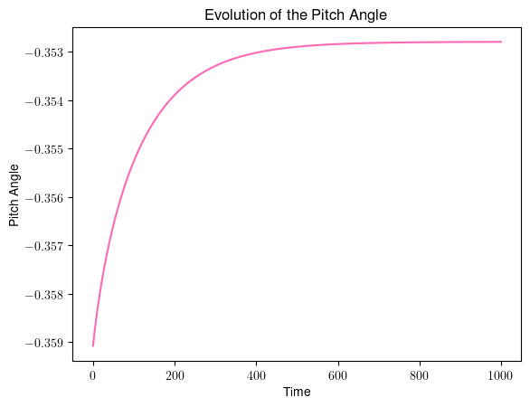

```python
def pitch_angle(br,bp,t):
    p = np.zeros(len(t))
    for i in range(len(t)):
        mr = np.mean(br[:,i])
        mp = np.mean(bp[:,i])
        p[i] = np.arctan(mr/mp)
    plt.plot(t,p,color='hotpink')
    plt.xlabel('Time')
    plt.ylabel('Pitch Angle')
    plt.title('Evolution of the Pitch Angle')
    plt.show()
pitch_angle(br,bp,t)
```

It is interesting to see that the pitch angle evolves into a constant over a long time.

## **Task-2: Solving the mean field dynamo equation including the $\alpha-\Omega$ effect**

##### **Defining the mesh**

```python
# Defining the mesh parameters
h = 0.1 # step size along z-axis
k = 0.2 # step size along t-axis
eta = 1e-2 # Defining the eta parameter
z = np.arange(-1,1+h,h) # Taking z from -1 to 1 a.u.
t = np.arange(0,800+k,k) # Taking t from 0 to 2000 a.u
M = len(t) # Number of grid points along t-axis
N = len(z) # Number of grid points along z-axis
# Creating the mesh
br = np.zeros((N,M))
bp = np.zeros((N,M))
```

##### **Initial Condition and Boundary Conditions**

While I am taking a sinusoidal initial condition for the $B_r$ component, I am going for a quadratic function for the $B_\phi$ component. The boundary conditions are still the same Dirichlet Boundary conditions.

```python
# Defining the initial condition for B_r and B_p
def initial_br(z):
    return 0.5*np.sin(2*z*np.pi/180)

def initial_bp(z):
    return  0.5*z**2 + z
```

```python
# Incorporating the Boundary Conditions
br[0,:] = 0
br[-1,:] = 0
bp[0,:] = 0
bp[-1,:] = 0

# Incorporating the Initial Conditions
br[:,0] = initial_br(z)
bp[:,0] = initial_bp(z)
```

##### Defining other parameters which will remain constant over the entire time evolution

```python
S,D = 10, -10
def alpha(z,alpha_0 = 0.5):
    return alpha_0*np.sin(z)
```

##### Defining the RHS of the coupled equations

```python
def f1(u,v,dx,t,z):
    global eta
    d1 = np.zeros_like(u)
    d2 = np.zeros_like(v)
    for i in range(1,len(u)-1):
        d1[i] = alpha(z[i])*eta*(v[i+1] - v[i-1])/(2*dx)
        d2[i] = eta*(u[i - 1] - 2 * u[i] + u[i + 1])/dx**2
    return (-d1+d2)

def f2(u,v,dx,t,D):
    global eta, S
    d = np.zeros_like(u)
    for i in range(1,len(u)-1):
        d = D*S*u + eta*(v[i - 1] - 2 * v[i] + v[i + 1])/dx**2
    return d
```

##### **Implementing fourth order Runge-Kutta algorithm for a coupled differential equation**

```python
def RK4_coupled(u,v,t,dx,dt,f1,f2,z,D):
    k1 = dt*f1(u,v,dx,t,z)
    l1 = dt*f2(u,v,dx,t,D)
    k2 = dt*f1(u+k1*0.5,v+l1*0.5,dx,t+dt/2,z)
    l2 = dt*f2(u+k1*0.5,v+l1*0.5,dx,t+dt/2,D)
    k3 = dt*f1(u+k2*0.5,v+l2*0.5,dx,t+dt/2,z)
    l3 = dt*f2(u+k2*0.5,v+l2*0.5,dx,t+dt/2,D)
    k4 = dt*f1(u+k3,v+l3,dx,t+dt/2,z)
    l4 = dt*f2(u+k3,v+l3,dx,t+dt/2,D)

    k = (1/6)*(k1+2*k2+2*k3+k4)
    l = (1/6)*(l1+2*l2+2*l3+l4)

    u_new = u + k
    v_new = v + l

    return u_new,v_new
```

```python
for i in tqdm(range(1,M-1)):
    u = br[:,i-1]
    v = bp[:,i-1]
    next_t = t[i]
    br[:,i], bp[:,i] = RK4_coupled(u,v,next_t,h,k,f1,f2,z,-10)
```

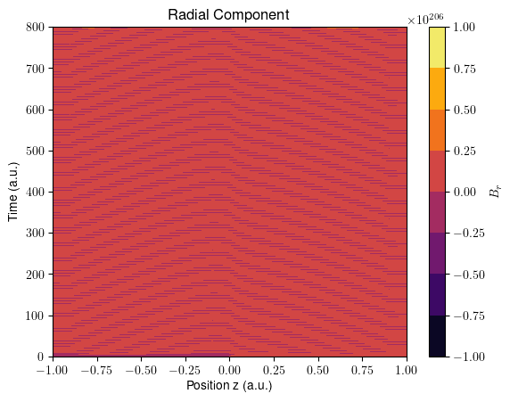

```python
plt.contourf(z,t,br.transpose(),cmap='inferno')
plt.ylabel('Time (a.u.)')
plt.xlabel('Position z (a.u.)')
# plt.ylim(0,200)
plt.colorbar(label='$B_r$')
plt.title('Radial Component')
plt.show()
```

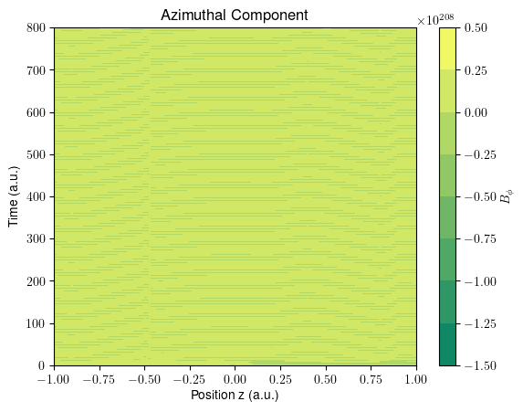

```python
plt.contourf(z,t,bp.transpose(),cmap='summer')
plt.ylabel('Time (a.u.)')
plt.xlabel('Position z (a.u.)')
plt.colorbar(label='$B_\phi$')
plt.title('Azimuthal Component')
plt.show()
```

Looking at animations showing the evolution of the magnetic field can give us a better feel of how the solution converges to an exponentially increasing one:

[figure not shown]

```python
def decay(D):
    # Defining the mesh parameters
    h = 0.06 # step size along z-axis
    k = 0.08 # step size along t-axis
    eta = 1e-2 # Defining the eta parameter
    z = np.arange(-1,1+h,h) # Taking z from -1 to 1 a.u.
    t = np.arange(0,100+k,k) # Taking t from 0 to 100 a.u.
    M = len(t) # Number of grid points along t-axis
    N = len(z) # Number of grid points along z-axis
    # Creating the mesh
    br = np.zeros((N,M))
    bp = np.zeros((N,M))
    # Incorporating the Boundary Conditions
    br[0,:] = 0
    br[-1,:] = 0
    bp[0,:] = 0
    bp[-1,:] = 0
    S = 10
    # Incorporating the Initial Conditions
    br[:,0] = initial_br(z)
    bp[:,0] = initial_bp(z)

    for i in range(1,M-1):
        u = br[:,i-1]
        v = bp[:,i-1]
        next_t = t[i]
        br[:,i], bp[:,i] = RK4_coupled(u,v,next_t,h,k,f1,f2,z,D)

    bmid = (br[int(len(z)/2),:]**2 + bp[int(len(z)/2),:]**2)**0.5
    plt.plot(t,bmid,label=D)
    # a,b = np.polyfit(t,np.log(abs(bmid)),1)
```

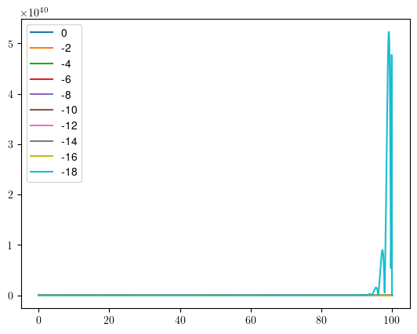

```python
D0 = np.arange(0,-20,-2)
dec = np.zeros(len(D0))
for i in tqdm(range(len(D0))):
    dec[i] = decay(D0[i])
plt.legend()
plt.show()
```

## **Task-3: Exploring the sensitivity of the solutions to the order of the Runge-Kutta algorithm**

The task essentially involves solving the same set of equations again and determining the right balance of accuracy and speed in the RK algorithm. I would start with the diffusion equation neglecting the $\alpha-\Omega$ effects and use different orders of RK algorithms to determine which one works the best. I would work with a smaller grid for this part. Later, I would see how the choice of the mesh itself affects the results. So, let's define the RK algorithms of the order 2,3,4(already defined),and 6 to see how things turn out.

```python
def RK2(u,t,dx,dt,f):
    k1 = dt*f(u,dx,t)
    k2 = dt*f(u+k1*0.5,dx,t+dt/2)
    un = u + k2
    return un

def RK3(u,t,dx,dt,f):
    k1 = dt*f(u,dx,t)
    k2 = dt*f(u+k1*0.5,dx,t+dt/2)
    k3 = dt*f(u+2*k2-k1,dx,t+dt/2)
    k = (1/6)*(k1+4*k2+k3)
    un = u + k
    return un

def RK6(u,t,dx,dt,f):
    k1 = dt*f(u,dx,t)
    k2 = dt*f(u+k1,dx,t+dt)
    k3 = dt*f(u+(3*k1+k2)/8,dx,t+dt/2)
    k4 = dt*f(u+(8*k1+2*k2+8*k3)/27,dx,t+2*dt/3)
    k5 = dt*f(u+(3*(3*21**0.5-7)*k1 - 8*(7-21**0.5)*k2 + 48*(7-21**0.5)*k3 - 3*(21 - (21)**0.5)*k4)/392,dx,t+(7-21**0.5)*dt/14)
    k6 = dt*f(u+(-5*(231+51*21**0.5)*k1 - 40*(7+21**0.5)*k2 - 320*21**0.5*k3 + 3*(21-121*21**0.5)*k4 + 392*(6+21**0.5)*k5)/1960,dx,t+(7+21**0.5)*dt/14)
    k7 = dt*f(u+(15*(22+7*21**0.5)*k1 + 120*k2 + 40*(7*21**0.5-5)*k3-63*(3*21**0.5 - 2)*k4 - 14*(49 + 9*21**0.5)*k5 + 70*(7-21**0.5)*k6)/180,dx,t+dt)
    k = (9*k1 + 64*k3 + 49*k5 + 49*k6 + 9*k7)/180
    un = u + k
    return un
```

```python
def test(f):
    # Defining the mesh parameters
    h = 0.05 # step size along z-axis
    k = 0.07 # step size along t-axis
    eta = 1e-2 # Defining the eta parameter
    z = np.arange(0,10+h,h) # Taking z from 0 to 10 a.u.
    t = np.arange(0,10+k,k) # Taking t from 0 to 10 a.u.
    M = len(t) # Number of grid points along t-axis
    N = len(z) # Number of grid points along z-axis
    # Creating the mesh
    br = np.zeros((N,M))
    bp = np.zeros((N,M))
    # Defining the initial condition for B_r and B_p
    def initial_br(z):
        return (z**2/2 - 10*z*np.sin(3*z*np.pi/180))*10

    def initial_bp(z):
        return 5*z - z**2/2
    # Incorporating the Boundary Conditions
    br[0,:] = 0
    br[-1,:] = 0
    bp[0,:] = 0
    bp[-1,:] = 0

    # Incorporating the Initial Conditions
    br[:,0] = initial_br(z)
    bp[:,0] = initial_bp(z)
    # Iteratively Solving the DE
    for i in tqdm(range(1,M-1)):
        u = br[:,i-1]
        v = bp[:,i-1]
        next_t = t[i]
        br[:,i] = f(u,next_t,h,k,x_der)
        bp[:,i] = f(v,next_t,h,k,x_der)
    return br,bp
```

```python
br1,bp1 = test(RK2)
```

```python
br2,bp2 = test(RK3)
```

```python
br3,bp3 = test(RK4)
```

```python
br4,bp4 = test(RK6)
```

Let's compare the final solutions to get an idea of the overall process.

[figure not shown]

```python
plt.plot(np.arange(0,10+0.1,0.1),br1[:,-2],label='RK2')
plt.plot(np.arange(0,10+0.1,0.1),br2[:,-2],label='RK3')
plt.plot(np.arange(0,10+0.1,0.1),br3[:,-2],label='RK4')
plt.plot(np.arange(0,10+0.1,0.1),br4[:,-2],label='RK6')
plt.xlabel('Position z (a.u.)')
plt.ylabel('$B_r$')
plt.legend()
plt.show()
```

```python
br1,bp1 = test(RK2)
br2,bp2 = test(RK3)
br3,bp3 = test(RK4)
br4,bp4 = test(RK6)
```

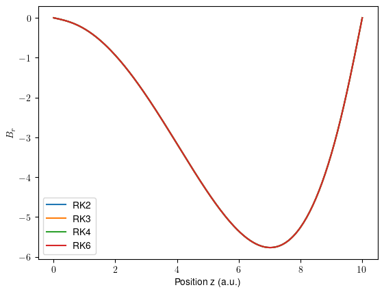

```python
plt.plot(np.arange(0,10+0.05,0.05),br1[:,-2],label='RK2')
plt.plot(np.arange(0,10+0.05,0.05),br2[:,-2],label='RK3')
plt.plot(np.arange(0,10+0.05,0.05),br3[:,-2],label='RK4')
plt.plot(np.arange(0,10+0.05,0.05),br4[:,-2],label='RK6')
plt.xlabel('Position z (a.u.)')
plt.ylabel('$B_r$')
plt.legend()
plt.show()
```

At this point, I would like to comment upon an interesting thing that came up quite frequently. When I started with the simulations in task-1, I faced a weird issue. The program didn't work for certain meshes I had defined. The computation would suddenly stop saying that there is an 'overflow' of data i.e., how values are propping while I evolved the system through time. It was a clear indication of the fact that the solution I was obtaining deviating strongly from the actual solution. After fiddling with the mesh parameters for a while I realised that keeping the time-steps too big was causing the divergence. Thus, my program worked only for $dt \le 0.2$. For time-steps greater than 0.2, my solution diverged greatly and an 'data overflow' error would pop up in the program window. Thus, determining the optimum time-step and position step sizes is an important task before one can proceed with obtaining the solutions.

Now, we can proceed to compare the RK algorithms of different orders for the coupled mean field dynamo equations. Let's define RK2, RK3 and RK6 for a coupled system of differential equations.

```python
def RK2_coupled(u,v,t,dx,dt,f1,f2,z,D):
    k1 = dt*f1(u,v,dx,t,z)
    l1 = dt*f2(u,v,dx,t,D)
    k2 = dt*f1(u+k1*0.5,v+l1*0.5,dx,t+dt/2,z)
    l2 = dt*f2(u+k1*0.5,v+l1*0.5,dx,t+dt/2,D)

    u_new = u + k2
    v_new = v + l2

    return u_new,v_new

def RK3_coupled(u,v,t,dx,dt,f1,f2,z,D):
    k1 = dt*f1(u,v,dx,t,z)
    l1 = dt*f2(u,v,dx,t,D)
    k2 = dt*f1(u+k1*0.5,v+l1*0.5,dx,t+dt/2,z)
    l2 = dt*f2(u+k1*0.5,v+l1*0.5,dx,t+dt/2,D)
    k3 = dt*f1(u+2*k2-k1,v+2*l2-l1,dx,t+dt/2,z)
    l3 = dt*f2(u+2*k2-k1,v+2*l2-l1,dx,t+dt/2,D)

    k = (1/6)*(k1+4*k2+k3)
    l = (1/6)*(l1+4*l2+l3)

    u_new = u + k
    v_new = v + l

    return u_new,v_new

def RK6_coupled(u,v,t,dx,dt,f1,f2,z,D):
    k1 = dt*f1(u,v,dx,t,z)
    l1 = dt*f2(u,v,dx,t,D)
    k2 = dt*f1(u+k1,v+l1,dx,t+dt,z)
    l2 = dt*f2(u+k1,v+l1,dx,t+dt,D)
    k3 = dt*f1(u + (3*k1+k2)/8,v + (3*l1+l2)/8,dx,t+dt/2,z)
    l3 = dt*f2(u + (3*k1+k2)/8,v + (3*l1+l2)/8,dx,t+dt/2,D)
    k4 = dt*f1(u+(8*k1+2*k2+8*k3)/27,v+(8*l1+2*l2+8*l3)/27,dx,t+2*dt/3,z)
    l4 = dt*f2(u+(8*k1+2*k2+8*k3)/27,v+(8*l1+2*l2+8*l3)/27,dx,t+2*dt/3,D)
    k5 = dt*f1(u+(3*(3*21**0.5-7)*k1 - 8*(7-21**0.5)*k2 + 48*(7-21**0.5)*k3 - 3*(21 - (21)**0.5)*k4)/392,v+(3*(3*21**0.5-7)*l1 - 8*(7-21**0.5)*l2 + 48*(7-21**0.5)*l3 - 3*(21 - (21)**0.5)*l4)/392,dx,t+(7-21**0.5)*dt/14,z)
    l5 = dt*f2(u+(3*(3*21**0.5-7)*k1 - 8*(7-21**0.5)*k2 + 48*(7-21**0.5)*k3 - 3*(21 - (21)**0.5)*k4)/392,v+(3*(3*21**0.5-7)*l1 - 8*(7-21**0.5)*l2 + 48*(7-21**0.5)*l3 - 3*(21 - (21)**0.5)*l4)/392,dx,t+(7-21**0.5)*dt/14,D)
    k6 = dt*f1(u+(-5*(231+51*21**0.5)*k1 - 40*(7+21**0.5)*k2 - 320*21**0.5*k3 + 3*(21-121*21**0.5)*k4 + 392*(6+21**0.5)*k5)/1960,v+(-5*(231+51*21**0.5)*l1 - 40*(7+21**0.5)*l2 - 320*21**0.5*l3 + 3*(21-121*21**0.5)*l4 + 392*(6+21**0.5)*l5)/1960,dx,t+(7+21**0.5)*dt/14,z)
    l6 = dt*f2(u+(-5*(231+51*21**0.5)*k1 - 40*(7+21**0.5)*k2 - 320*21**0.5*k3 + 3*(21-121*21**0.5)*k4 + 392*(6+21**0.5)*k5)/1960,v+(-5*(231+51*21**0.5)*l1 - 40*(7+21**0.5)*l2 - 320*21**0.5*l3 + 3*(21-121*21**0.5)*l4 + 392*(6+21**0.5)*l5)/1960,dx,t+(7+21**0.5)*dt/14,D)
    k7 = dt*f1(u+(15*(22+7*21**0.5)*k1 + 120*k2 + 40*(7*21**0.5-5)*k3-63*(3*21**0.5 - 2)*k4 - 14*(49 + 9*21**0.5)*k5 + 70*(7-21**0.5)*k6)/180,v+(15*(22+7*21**0.5)*l1 + 120*l2 + 40*(7*21**0.5-5)*l3-63*(3*21**0.5 - 2)*l4 - 14*(49 + 9*21**0.5)*l5 + 70*(7-21**0.5)*l6)/180,dx,t+dt,z)
    l7 = dt*f2(u+(15*(22+7*21**0.5)*k1 + 120*k2 + 40*(7*21**0.5-5)*k3-63*(3*21**0.5 - 2)*k4 - 14*(49 + 9*21**0.5)*k5 + 70*(7-21**0.5)*k6)/180,v+(15*(22+7*21**0.5)*l1 + 120*l2 + 40*(7*21**0.5-5)*l3-63*(3*21**0.5 - 2)*l4 - 14*(49 + 9*21**0.5)*l5 + 70*(7-21**0.5)*l6)/180,dx,t+dt,D)
    k = (9*k1 + 64*k3 + 49*k5 + 49*k6 + 9*k7)/180
    l = (9*l1 + 64*l3 + 49*l5 + 49*l6 + 9*l7)/180

    u_new = u + k
    v_new = v + l

    return u_new, v_new
```

```python
def test_coupled(f):
    # Defining the mesh parameters
    h = 0.05 # step size along z-axis
    k = 0.07 # step size along t-axis
    eta = 1e-2 # Defining the eta parameter
    z = np.arange(-1,1+h,h) # Taking z from -1 to 1 a.u.
    t = np.arange(0,10+k,k) # Taking t from 0 to 100 a.u.
    M = len(t) # Number of grid points along t-axis
    N = len(z) # Number of grid points along z-axis
    # Creating the mesh
    br = np.zeros((N,M))
    bp = np.zeros((N,M))
    # Incorporating the Boundary Conditions
    br[0,:] = 0
    br[-1,:] = 0
    bp[0,:] = 0
    bp[-1,:] = 0
    S = 10
    D = -10
    # Incorporating the Initial Conditions
    br[:,0] = initial_br(z)
    bp[:,0] = initial_bp(z)

    for i in tqdm(range(1,M-1)):
        u = br[:,i-1]
        v = bp[:,i-1]
        next_t = t[i]
        br[:,i], bp[:,i] = f(u,v,next_t,h,k,f1,f2,z,D)

    return br,bp
```

```python
br12,bp12 = test_coupled(RK2_coupled)
br22,bp22 = test_coupled(RK3_coupled)
br32,bp32 = test_coupled(RK4_coupled)
br42,bp42 = test_coupled(RK6_coupled)
```

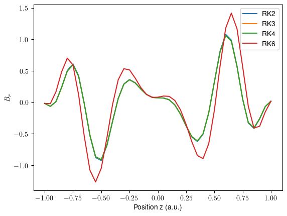

```python
plt.plot(np.arange(-1,1+0.05,0.05),br12[:,-2],label='RK2')
plt.plot(np.arange(-1,1+0.05,0.05),br22[:,-2],label='RK3')
plt.plot(np.arange(-1,1+0.05,0.05),br32[:,-2],label='RK4')
plt.plot(np.arange(-1,1+0.05,0.05),br42[:,-2],label='RK6')
plt.xlabel('Position z (a.u.)')
plt.ylabel('$B_r$')
plt.legend()
plt.show()
```

## **References**

[1] Shukurov, A., & Subramanian, K. (2021). *Astrophysical Magnetic Fields: From Galaxies to the Early Universe.* Cambridge: Cambridge University Press.  
[2] Chen, F. F. (1984). *Introduction to plasma physics and controlled fusion (Vol. 1, pp. 19-51).* New York: Plenum press.  
[3] Luther, H. (1968). *An explicit sixth-order Runge-Kutta formula*. Mathematics of Computation, 22(102), 434–436.  
[4] Runge-Kutta methods. Birne Binegar. *In LECTURE 21.* https://math.okstate.edu/people/binegar/4513-F98/4513-l21.pdf